# W3cubDocs

/Web APIs

# ReportingObserver

The `ReportingObserver` interface of the Reporting API allows you to collect and access reports.

## Constructor

**`ReportingObserver()`**

Creates a new `ReportingObserver` object instance, which can be used to collect and access reports.

## Instance properties

*This interface has no properties defined on it.*

## Instance methods

**`ReportingObserver.disconnect()`**

Stops a reporting observer that had previously started observing from collecting reports.

**`ReportingObserver.observe()`**

Instructs a reporting observer to start collecting reports in its report queue.

**`ReportingObserver.takeRecords()`**

Returns the current list of reports contained in the observer's report queue, and empties the queue.

## Events

*This interface has no events that fire on it.*

## Examples

In our deprecation_report.html example, we create a simple reporting observer to observe usage of deprecated features on our web page:

js

```
const options = {
  types: ["deprecation"],
  buffered: true,
};

const observer = new ReportingObserver((reports, observer) => {
  reportBtn.onclick = () => displayReports(reports);
}, options);
```

We then tell it to start observing reports using `ReportingObserver.observe()`; this tells the observer to start collecting reports in its report queue, and runs the callback function specified inside the constructor:

js

```
observer.observe();
```

Later on in the example we deliberately use the deprecated version of `MediaDevices.getUserMedia()`:

js

```
if (navigator.mozGetUserMedia) {
  navigator.mozGetUserMedia(constraints, success, failure);
} else {
  navigator.getUserMedia(constraints, success, failure);
}
```

This causes a deprecation report to be generated; because of the event handler we set up inside the `ReportingObserver()` constructor, we can now click the button to display the report details.

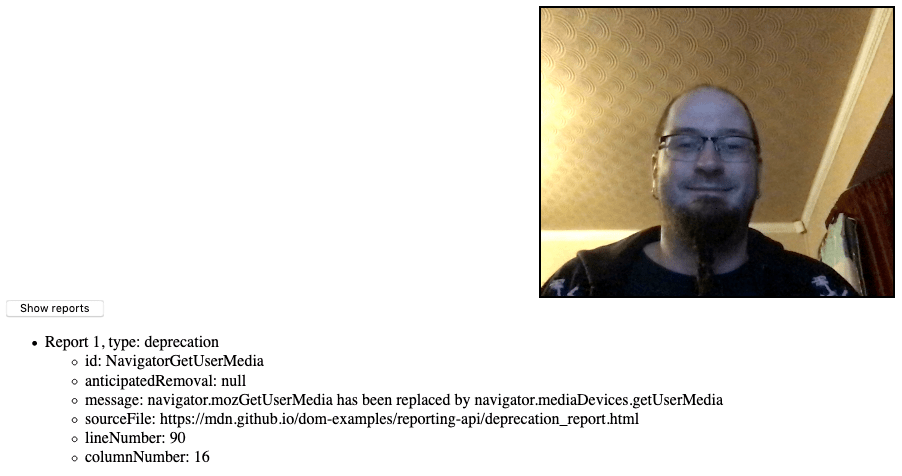

**Note:** If you look at the [complete source code](https://github.com/mdn/dom-examples/blob/main/reporting-api/deprecation_report.html), you'll notice that we actually call the deprecated `getUserMedia()` method twice. After the first time we call `ReportingObserver.takeRecords()`, which returns the first generated report and empties the queue. Because of this, when the button is pressed only the second report is listed.

## Specifications

| Specification |
| --- |
| Reporting API # interface-reporting-observer |

## Browser compatibility

|  | Desktop Chrome | Desktop Edge | Desktop Firefox | Desktop Internet Explorer | Desktop Opera | Desktop Safari | Mobile WebView Android | Mobile Chrome Android | Mobile Firefox for Android | Mobile Opera Android | Mobile Safari on IOS | Mobile Samsung Internet |
| --- | --- | --- | --- | --- | --- | --- | --- | --- | --- | --- | --- | --- |
| `ReportingObserver` | 69 | 79 | No | No | 56 | 16.4 | 69 | 69 | No | 48 | 16.4 | 10.0 |
| `ReportingObserver` | 69 | 79 | No | No | 56 | 16.4 | 69 | 69 | No | 48 | 16.4 | 10.0 |
| `disconnect` | 69 | 79 | No | No | 56 | 16.4 | 69 | 69 | No | 48 | 16.4 | 10.0 |
| `observe` | 69 | 79 | No | No | 56 | 16.4 | 69 | 69 | No | 48 | 16.4 | 10.0 |
| `takeRecords` | 69 | 79 | No | No | 56 | 16.4 | 69 | 69 | No | 48 | 16.4 | 10.0 |
| `worker_support` | 84 | 84 | No | No | 70 | No | 84 | 84 | No | No | No | 14.0 |

## See also

- Reporting API

© 2005–2023 MDN contributors.  
Licensed under the Creative Commons Attribution-ShareAlike License v2.5 or later.  
https://developer.mozilla.org/en-US/docs/Web/API/ReportingObserver